# Hw2

Anish Mohan

May 17, 2016

1. Q1
- Advantages:
  - Fast: Since only a subset of variables are selected, trees can be built comparitively (compared to full set tree with all variables) quickly
  - Parallizable: Each selection of subset of variables can be independent, hence trees for Random Forests can be calculated independently.
  - Less likely to overfit the data since in each iteration only a smaller set of variables are selected
- Disadvantages:
  - Interpretability becomes difficult as only a subset of variables are selected for each iteration.
  - Addition of a new tunable parameter i.e the number of variables to be chosen. Performance will depend on the value of parameter.
  - Potentially more bias in construction of each tree as we only consider a subset of variables.
- One can introduce additional tree variation in the forest by selecting a subset of training data in each iteration. The results are equivalent to randomly selecting subsets of variables.
2. Q2

If number of predictors are greater than the number of observations in the training sample, then to an extent we have an ill-posed problem. Here are some of the challenges: + High variability in the estimates of risk when evaluated on different random samples + Some of the predictors are guaranteed not to not have any contribution in the sample points.

- Regularization helps here by placing a restriction on the joint solution values. i.e it helps by constraining the number of variables chosen or the coefficients of variables chosen for building the functions.
- Benefits of regularization
  - Regularization also will help when the output response is only dependent on few input parameters, but measurements of many extraneous variables are available.
  - Regularization also helps in minimizing the impact of noise.
- Disadvantages of regularization:
  - Regularization requires prior knowledge e.g # of useful variables, # of variables with zero or near-zero coefficients. These parameters go in choosing the regularizing function. The priors could be easily be wrong. For e.g for best subset selection we have to choose the number of variables at each iteration. If the true number of dependent variables are larger than the subsets we chose, the output will have a high error rate.
- Sparsity is a reasonable assumption in boosting as this method relies on a limited number of weak classifiers.

  There are two possiblities:
  - Actual distribution is not sparse: In this scenario, making the sparsity assumption would impact the results significantly. However, if the actual distribution is not sparse, most methods including Boosting would have problem dealing with the data.
  - Actual distribution is sparse: In this scenario, ground truth matches our assumption and boosting will work well here
- Sparsity might be a reasonable assumption for boosting but might not a reasoble assumption for many other methods. Results are generally poor when sparsity assumptions are made and the distributuon is not sparse.
3. +Q3

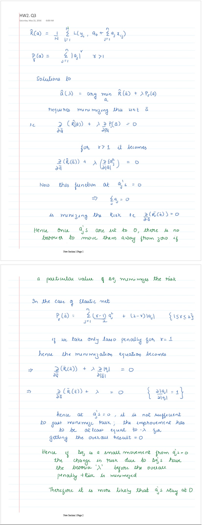

4. - Q4

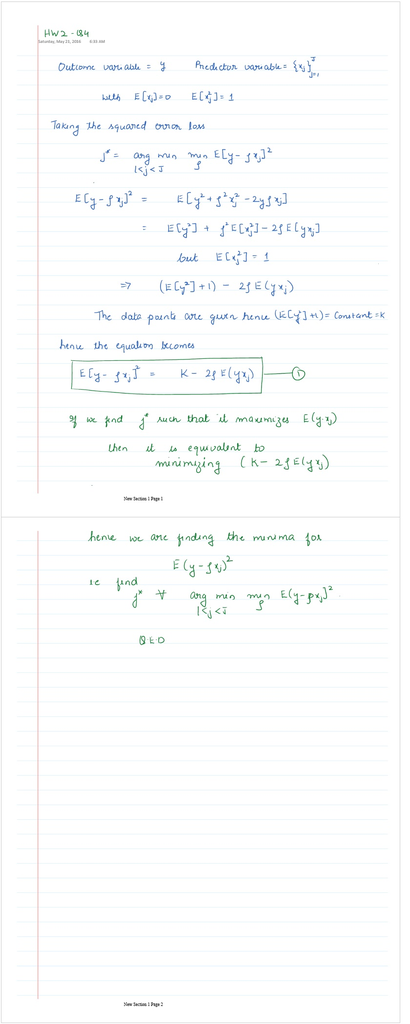

5. - Q5

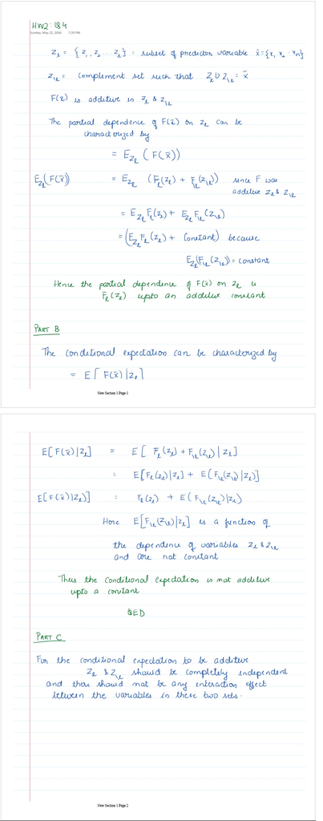

6. Q6
- 6a.

  ```r
  library(gbm)
  inspam=read.csv("Spam_Train.txt")
  spname<-c ("make", "address", "all", "3d", "our", "over", "remove",
            "internet","order", "mail", "receive", "will",
            "people", "report", "addresses","free", "business",
            "email", "you", "credit", "your", "font","000","money",
            "hp", "hpl", "george", "650", "lab", "labs",
            "telnet", "857", "data", "415", "85", "technology", "1999",
            "parts","pm", "direct", "cs", "meeting", "original", "project",
            "re","edu", "table", "conference", ";", "(", "[", "!", "$", "#",
            "CAPAVE", "CAPMAX", "CAPTOT","type")
  colnames(inspam)=spname


  set.seed(1)
  x=inspam[sample(nrow(inspam)),]

  set.seed(1)
  gbm0=gbm(type~.,data = x,interaction.depth = 4, shrinkage =0.001, n.trees=2500, cv.folds=5, distribution="bernoulli", verbose=F)
  gbm0.predict=predict(gbm0,x,type="response",n.trees = 300)
  trainresp=rep(0,length(gbm0.predict))
  trainresp[gbm0.predict>=0.5]=1
  conftable=table(trainresp, x$type)
  best.iter_train=gbm.perf(gbm0,method="cv")
  ```

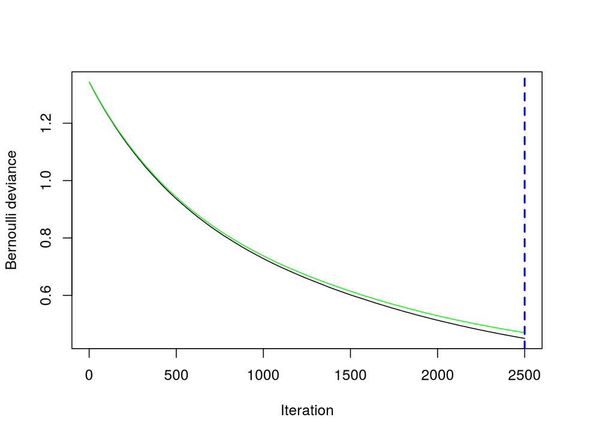

  ```r
  overallerror=(conftable[1,2]+conftable[1,2])/sum(conftable)
  nonspam_as_spam=(conftable[2,1])/sum(conftable[,1])
  spam_as_notspam=(conftable[1,2])/sum(conftable[,2])
  print(paste0("Overall Error Rate=",overallerror))
  ```

  ```
  ## [1] "Overall Error Rate=0.263535551206784"
  ```

  ```r
  print(paste0("Non-spam marked as spam=",nonspam_as_spam))
  ```

  ```
  ## [1] "Non-spam marked as spam=0.012987012987013"
  ```

  ```r
  print(paste0("Spam marked as not-spam=",spam_as_notspam))
  ```

  ```
  ## [1] "Spam marked as not-spam=0.331691297208539"
  ```

```r
    set.seed(1)
    inspamtest=read.csv("Spam.Test.txt")
    spname<-c ("make", "address", "all", "3d", "our", "over", "remove",
              "internet","order", "mail", "receive", "will",
              "people", "report", "addresses","free", "business",
              "email", "you", "credit", "your", "font","000","money",
              "hp", "hpl", "george", "650", "lab", "labs",
              "telnet", "857", "data", "415", "85", "technology", "1999",
              "parts","pm", "direct", "cs", "meeting", "original", "project",
              "re","edu", "table", "conference", ";", "(", "[", "!", "$", "#",
              "CAPAVE", "CAPMAX", "CAPTOT","type")
    colnames(inspamtest)=spname
    w=inspamtest[sample(nrow(inspamtest)),]

    #Predicting using gbm from training
    gbm0.test.predict=predict(gbm0,w,type="response",n.trees = best.iter_train)
    trainresp1=rep(0,length(gbm0.test.predict))
    trainresp1[gbm0.test.predict>=0.5]=1
    conftable2=table(trainresp1, w$type)

    overallerror=(conftable2[1,2]+conftable2[1,2])/sum(conftable2)
    nonspam_as_spam=(conftable2[2,1])/sum(conftable2[,1])
    spam_as_notspam=(conftable2[1,2])/sum(conftable2[,2])
    print(paste0("Overall Error Rate=",overallerror))
```

```
## [1] "Overall Error Rate=0.0365296803652968"
```

```r
    print(paste0("Non-spam marked as spam=",nonspam_as_spam))
```

```
## [1] "Non-spam marked as spam=0.0240174672489083"
```

```r
    print(paste0("Spam marked as not-spam=",spam_as_notspam))
```

```
## [1] "Spam marked as not-spam=0.0453808752025932"
```

[output not shown]

- 6b. i

  ```r
  set.seed(1)
  wghts=rep(1,length(x$type))

  wghts[x$type==0]=25;
  gbm1=gbm(type~.,data = x,interaction.depth = 4, shrinkage =0.001, weights=wghts, n.trees=2500,cv.folds=5, distribution="bernoulli", verbose=F)

  best.iter_train=gbm.perf(gbm1,method="cv")
  ```

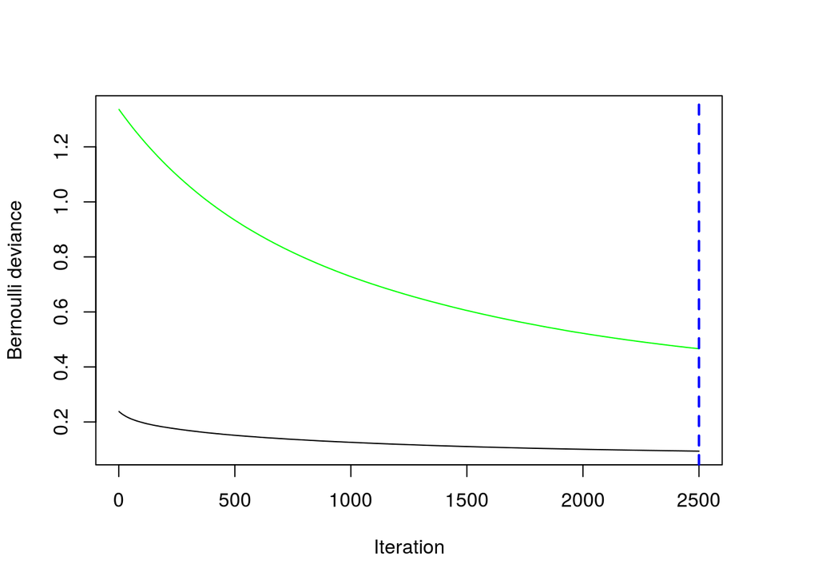

  ```r
  gbm1.predict=predict(gbm1,w,type="response",n.trees = best.iter_train)
  trainresp1=rep(0,length(gbm1.predict))
  trainresp1[gbm1.predict>=0.5]=1
  conftable2=table(trainresp1, w$type)

  overallerror=(conftable2[1,2]+conftable2[1,2])/sum(conftable2)
  nonspam_as_spam=(conftable2[2,1])/sum(conftable2[,1])
  spam_as_notspam=(conftable2[1,2])/sum(conftable2[,2])
  print(paste0("Overall Error Rate=",overallerror))
  ```

  ```
  ## [1] "Overall Error Rate=0.377038486627528"
  ```

  ```r
  print(paste0("Non-spam marked as spam=",nonspam_as_spam))
  ```

  ```
  ## [1] "Non-spam marked as spam=0.00218340611353712"
  ```

  ```r
  print(paste0("Spam marked as not-spam=",spam_as_notspam))
  ```

  ```
  ## [1] "Spam marked as not-spam=0.46839546191248"
  ```

  - By giving more weight to missclassifcation of Non-Spam as a spam mail, the overall accuracy of the model is reduced however, we decreased the missclassification error due to a non-spam mail being marked as a spam mail.
- 6b. ii

  ```r
  impvar=summary(gbm1)
  ```

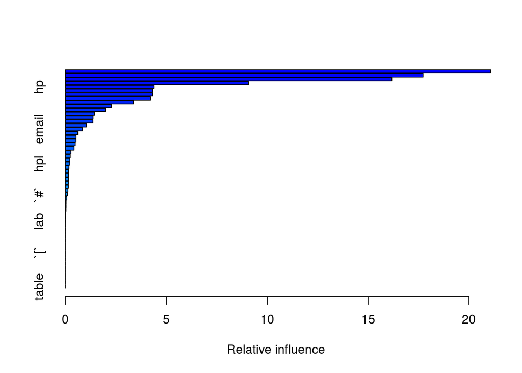

  ```r
  impvar[1:5,]
  ```

  ```
  ##           var   rel.inf
  ## `$`       `$` 21.076968
  ## remove remove 17.725132
  ## `!`       `!` 16.174501
  ## CAPAVE CAPAVE  9.072380
  ## hp         hp  4.400417
  ```

  - The 3 most important variables seems to be having following words in the spam email:
    - $ string (#53)
    - phrase: remove (#7)
    - ! exclamation mark. (#52)
- 6b iii

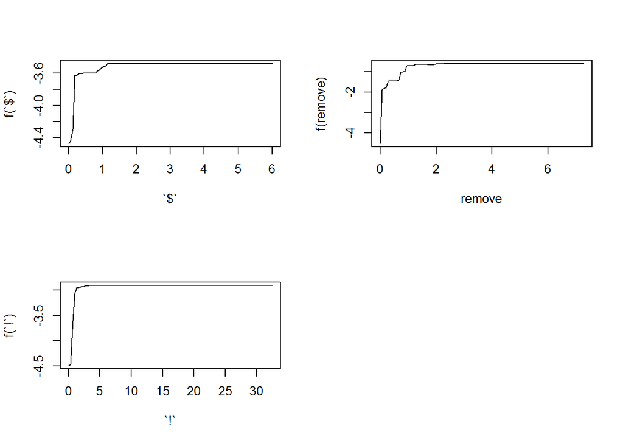

  ```r
  par(mfrow=c(2,2))
  plot(x=gbm1, i.var=53, n.trees=best.iter_train, main="Partial Dependence  of '$'")
  plot(x=gbm1, i.var=7, n.trees=best.iter_train, main="Partial Dependence  of Phrase 'Remove'")
  plot(x=gbm1, i.var=52, n.trees=best.iter_train, main="Partial Dependence  of '!'")
  ```

  - There is a significant +ve correlation and mail having $ and probability of it being a spam email. This is also true for other two terms ie presence of “!” and word “Remove” has high correlation with the mail being a spam mail.

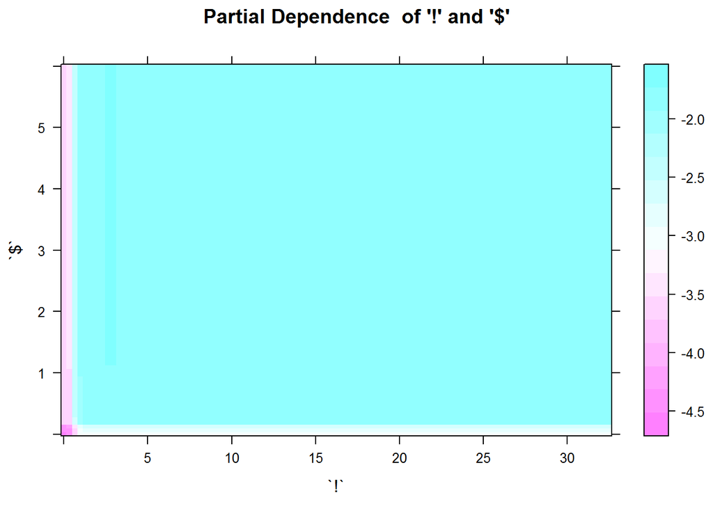

  ```r
  par(mfrow=c(2,2))
  plot(gbm1, c(52,53),best.iter_train, main="Partial Dependence  of '!' and '$'")
  ```

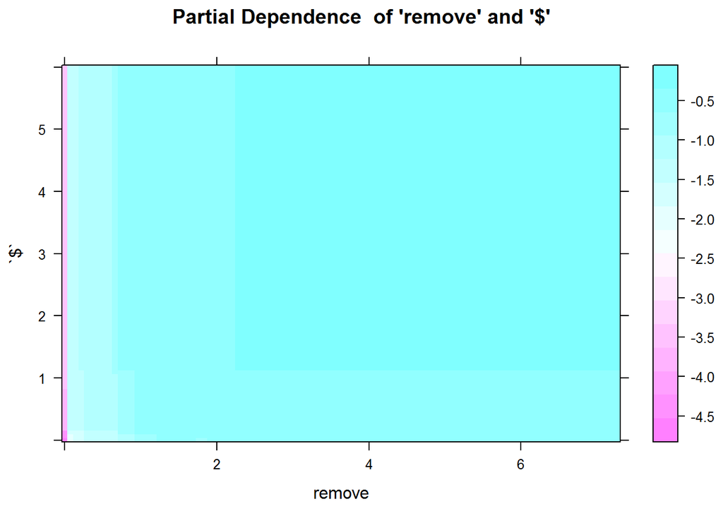

  ```r
  plot(gbm1, c(7,53),best.iter_train, main="Partial Dependence  of 'remove' and '$'")
  ```

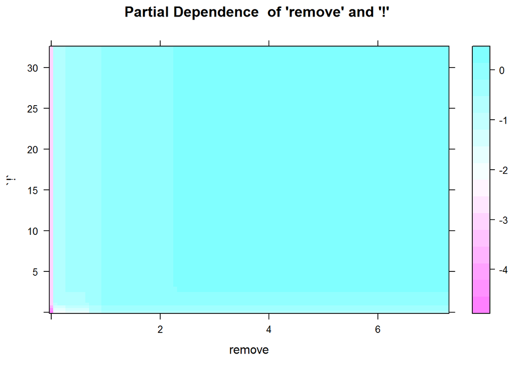

  ```r
  plot(gbm1, c(7,52),best.iter_train, main="Partial Dependence  of 'remove' and '!'")
  ```

  ```r
  inpcal=read.csv("California_Data.txt")
  calname=c("hval","inc","hage","#rooms","#bed","pop","occu","lat","long")
  colnames(inpcal)=calname
  set.seed(1)
  inpcal=inpcal[sample(nrow(inpcal)),]

  set.seed(1)
  gbmcal0=gbm(hval~.,data=inpcal, train.fraction=0.8, interaction.depth = 4, shrinkage = 0.001, n.trees=2500, cv.folds=5, distribution = "gaussian", verbose=F)

  best.iter=gbm.perf(gbmcal0,method="test")
  ```

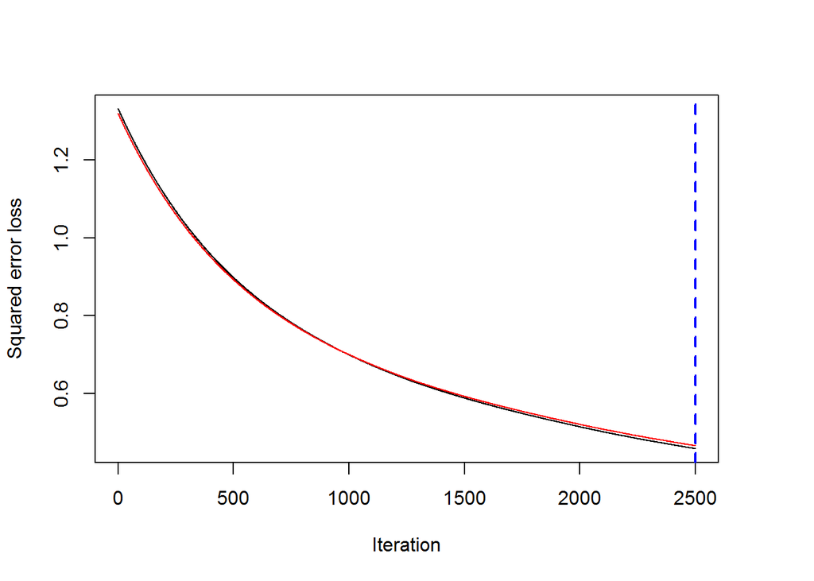

  ```r
  gbmcal0.predict=predict(gbmcal0,inpcal,n.trees = best.iter)

  # Error:
  mean((gbmcal0.predict-inpcal$hval)^2)
  ```

  ```
  ## [1] 0.4593195
  ```

  ```r
  print(paste0("Traning Error=",mean((gbmcal0.predict-inpcal$hval)^2)))
  ```

  ```
  ## [1] "Traning Error=0.459319450169259"
  ```

  - For this exercise, I have divided the data in to Test and training set. The gbm model is trained on the training set.
  - Training set Error is 0.459
- 7b.

```r
    par(mfrow=(c(1,1)))
    impvar=summary(gbmcal0)
```

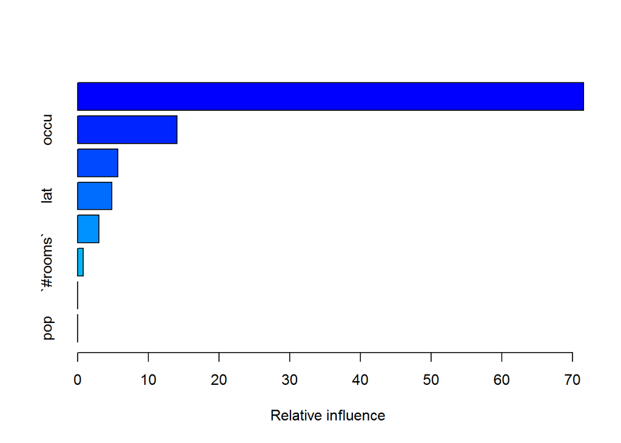

```r
    impvar[1:5,]
```

```
##       var   rel.inf
## inc   inc 71.557500
## occu occu 14.089388
## long long  5.686636
## lat   lat  4.866760
## hage hage  2.993203
```

```
+ Most important factors of influence on housing prices are:
  + Median Income of the block/neighborhood
  + Average occupancy
  + Longitude of the house location.
```

- 7c.

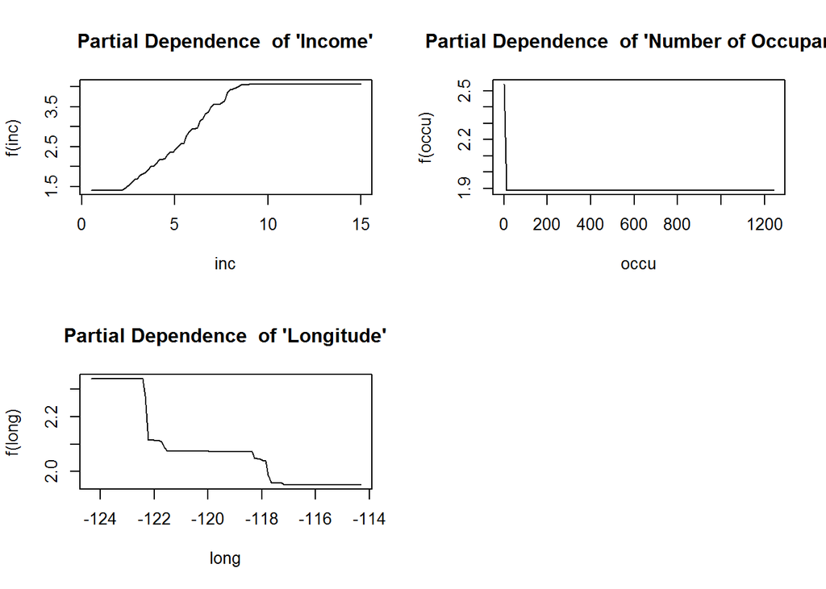

[output not shown]

```r
    par(mfrow=c(2,2))
    plot(x=gbmcal0, i.var=1, n.trees=best.iter, main="Partial Dependence  of 'Income'")
    plot(x=gbmcal0, i.var=6, n.trees=best.iter, main="Partial Dependence  of 'Number of Occupants")
    plot(x=gbmcal0, i.var=8, n.trees=best.iter, main="Partial Dependence  of 'Longitude'")
```

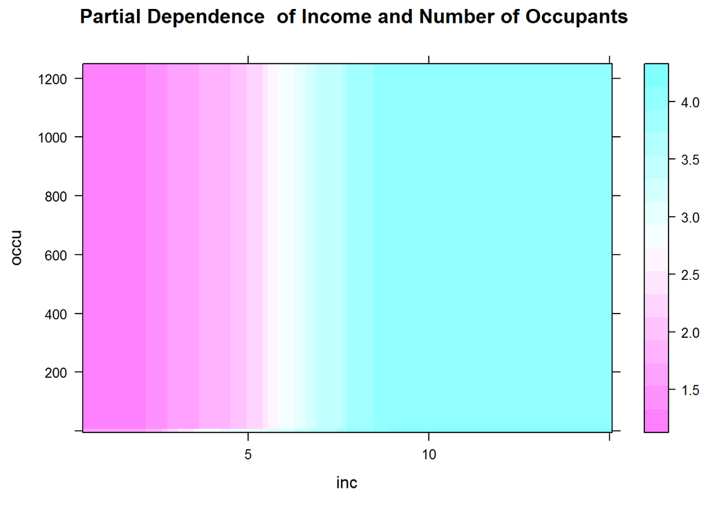

```r
    par(mfrow=c(2,2))
    plot(x=gbmcal0,c(1,6), n.trees=best.iter, main="Partial Dependence  of Income and Number of Occupants")
```

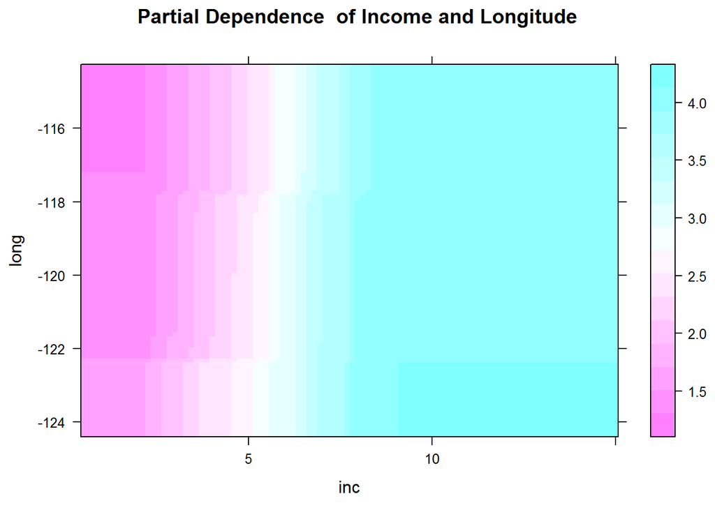

```r
    plot(x=gbmcal0, c(1,8), n.trees=best.iter, main="Partial Dependence  of Income and Longitude")
```

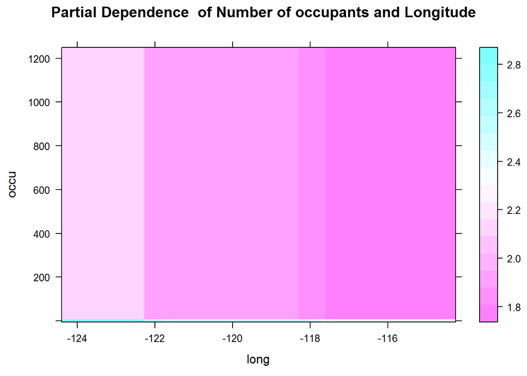

```
+ Lower Median income is a strong indicator for the Housing value and seems to be indpendent of the average occupancy in the region.
+ Lower Median income is a strong indicator for the Housing value and seems to be indpendent of longitudinal position in the region.
+ Eastwards Longitudinal position seems to be a stronger indicator of housing value  and seems to be independent of the average occupancy of the house
```

```r
    plot(x=gbmcal0, c(8,6), n.trees=best.iter, main="Partial Dependence  of Number of occupants and Longitude")
```

8. Q8
- 8a.

```r
    Income=read.csv("Income_Data.txt")
    ModIncome=data.frame(Inc=Income$X9,sex=Income$X2,marital=Income$X1,age=Income$X5,edu=Income$X4,occ=Income$X5.1,dwelltime=Income$X5.2,dual=Income$X3,hh=Income$X3.1,hh18=Income$X0,house=Income$X1.1,hometype=Income$X1.2,Ethnic=Income$X7,lang=Income$NA.)

    Inc=ModIncome$Inc
    sex=factor(ModIncome$sex, levels=1:2, labels=c("Male","Female"))
    marital=factor(ModIncome$marital, levels=1:5,labels=c("Married","live-in","Divorced","Seperated","Single"))
    age=factor(ModIncome$age,levels=1:7,labels=c("14-17","18-24","25-34","35-44","45-54","55-64","over 65"))
    edu=factor(ModIncome$edu,levels=1:6,labels=c("less grade 8","grade 9-11","grad high","1-3 college","College grad","Grad"))
    occ=factor(ModIncome$occ,levels=1:9,labels=c("Professional","Sales","laborer","Clerk","Home","Student","Military","Retired","Unemployed"))
    dwelltime=factor(ModIncome$dwelltime,levels=1:5,labels=c("<1year","1-3 years","4-6 years","7-10 years",">10 years"))
    dual=factor(ModIncome$dual, levels=1:3, labels=c("Not Married","Yes","No"))
    hh=factor(ModIncome$hh, levels=1:9, labels=c("1","2","3","4","5","6","7","8",">9"))
    hh18=factor(ModIncome$hh18, levels=1:9, labels=c("1","2","3","4","5","6","7","8",">9"))
    house=factor(ModIncome$house, levels=1:3, labels=c("Own","Rent","Live with family"))
    hometype=factor(ModIncome$house,levels=1:5, labels =c("House","Condo","Apa","Mobile","Other"))
    ethnic=factor(ModIncome$Ethnic, levels=1:8, labels=c("American Ind","Asian","Black","East indian","Hispanic","Pacific Island","White","Other"))
    lang=factor(ModIncome$lang,levels=1:3, labels=c("English","Spanish","Other"))

    FinalInc=data.frame(Inc=Inc,sex=sex,marital=marital,age=age,edu=edu,occ=occ, dwelltime=dwelltime, dual=dual, hh=hh, hh18=hh18,house=house, hometype=hometype,ethnic=ethnic, lang=lang)

    FinalInc=FinalInc[sample(nrow(FinalInc)),]

    set.seed(1)
    gbminc0=gbm(Inc~.,data=FinalInc, train.fraction=0.8, bag.fraction=0.5, interaction.depth = 4, shrinkage = 0.01, n.trees=2500, cv.folds=5, distribution = "gaussian", verbose=F)

    best.iter=gbm.perf(gbminc0,method="test")
```

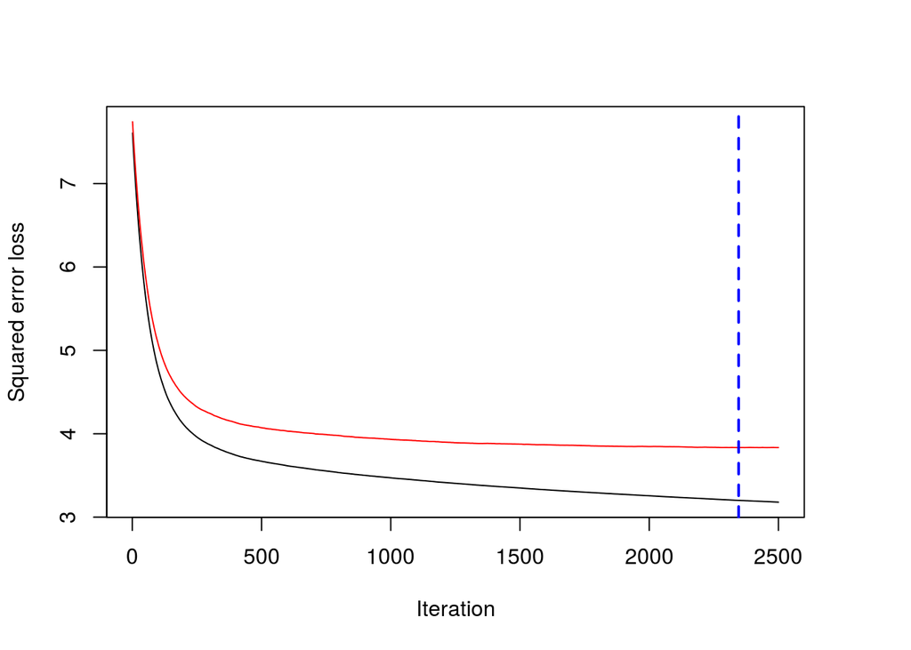

```r
    gbminc0.predict=predict(gbminc0,FinalInc,type="response", n.trees =best.iter)

    gbminc0.round=round(gbminc0.predict)

    # Error:
    mean((gbminc0.predict-FinalInc$Inc)^2)
```

```
## [1] 3.327438
```

```r
    print(paste0("Boosting Error=",mean((gbminc0.predict-FinalInc$Inc)^2)))
```

```
## [1] "Boosting Error=3.32743758231363"
```

```r
    #RPart tree error
    library(rpart)
    #Optimal tree was a tree with 18 nodes with cp=0.00199
    incfit=rpart(Inc~.,FinalInc, cp=0.00199)
    #summary(incfit)

    print(paste0("Error using trees:",7.69*0.5236 ))
```

```
## [1] "Error using trees:4.026484"
```

[output not shown]

- 8b.

```r
    summary(gbminc0)
```

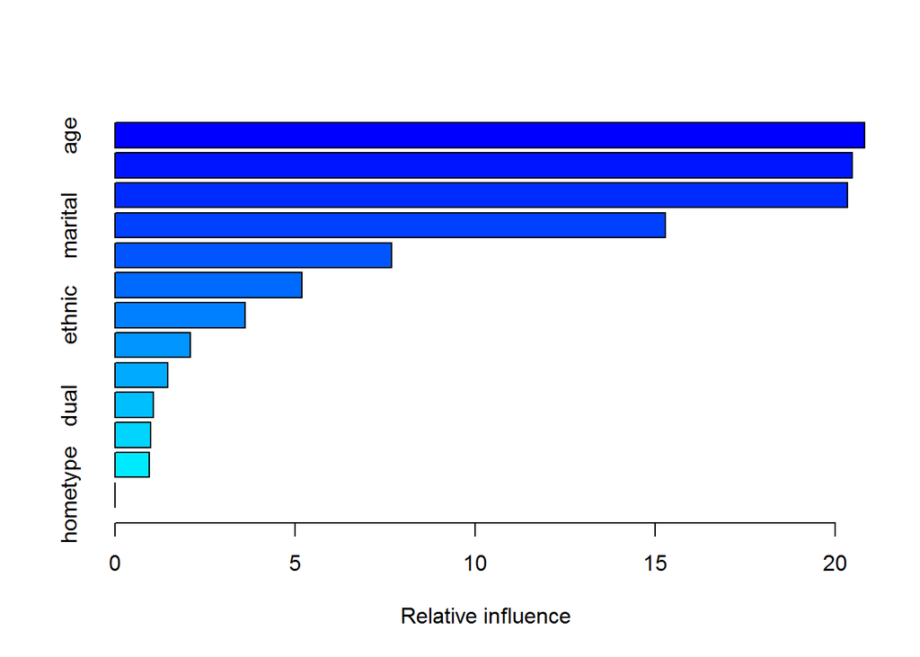

```
##                 var    rel.inf
## age             age 20.8187441
## house         house 20.4714322
## occ             occ 20.3370780
## marital     marital 15.2938822
## edu             edu  7.6890757
## hh               hh  5.2018256
## ethnic       ethnic  3.6137493
## dwelltime dwelltime  2.0942961
## hh18           hh18  1.4720530
## dual           dual  1.0740118
## lang           lang  0.9885550
## sex             sex  0.9452969
## hometype   hometype  0.0000000
```

```
+ The most important variables to predict income seems to be:
  + If the person owns the house or rents it or live with family.
  + Age of the person
  + Occupation

+ It is not inconsistent with national average results. Couple of possible reasons:
  + It could be very well that after adjustment to the critical factors mentioned here, women get paid less than men. i.e if a man and a woman have the same home ownership, age, occupation etc, men might still get paid higher.
  + Other possible reason could be that data from San-Francisco might not be representative of the national average data. San-Francisco is primarily tech based industry where the disparity between men/women salaries are less disparate than in other fields.
```

- 9a.

```r
Income=read.csv("Occupation_Data.txt")
  incnames<-c ("occ", "hometype", "sex", "marital", "age", "edu", "Inc",
              "dwelltime","dual", "hh", "hh18", "house",
              "ethnic", "lang")

    ModIncome=Income
    colnames(ModIncome)=incnames

    Inc=factor(ModIncome$Inc, levels=1:9, labels=c("<10K","10-15K","15-20K","20-25K","25-30K","30-40K","40-50K","50K-75K",">75K"))
    sex=factor(ModIncome$sex, levels=1:2, labels=c("Male","Female"))
    marital=factor(ModIncome$marital, levels=1:5,labels=c("Married","live-in","Divorced","Seperated","Single"))
    age=factor(ModIncome$age,levels=1:7,labels=c("14-17","18-24","25-34","35-44","45-54","55-64","over 65"))
    edu=factor(ModIncome$edu,levels=1:6,labels=c("less grade 8","grade 9-11","grad high","1-3 college","College grad","Grad"))
    occ=factor(ModIncome$occ,levels=1:9,labels=c("Professional","Sales","laborer","Clerk","Home","Student","Military","Retired","Unemployed"))
    dwelltime=factor(ModIncome$dwelltime,levels=1:5,labels=c("<1year","1-3 years","4-6 years","7-10 years",">10 years"))
    dual=factor(ModIncome$dual, levels=1:3, labels=c("Not Married","Yes","No"))
    hh=factor(ModIncome$hh, levels=1:9, labels=c("1","2","3","4","5","6","7","8",">9"))
    hh18=factor(ModIncome$hh18, levels=1:9, labels=c("1","2","3","4","5","6","7","8",">9"))
    house=factor(ModIncome$house, levels=1:3, labels=c("Own","Rent","Live with family"))
    hometype=factor(ModIncome$house,levels=1:5, labels =c("House","Condo","Apa","Mobile","Other"))
    ethnic=factor(ModIncome$Ethnic, levels=1:8, labels=c("American Ind","Asian","Black","East indian","Hispanic","Pacific Island","White","Other"))
    lang=factor(ModIncome$lang,levels=1:3, labels=c("English","Spanish","Other"))

    FinalInc=ModIncome

    train=sample(1:nrow(FinalInc),7000)
    test=-train

    Finalocc.train=FinalInc[train,]
    Finalocc.test=FinalInc[test,]

    set.seed(1)
    gbmocc0=gbm(occ~.,data=Finalocc.train, bag.fraction=0.5, interaction.depth = 4, shrinkage = 0.01, n.trees=2500, cv.folds=5, distribution = "multinomial", verbose=F)

    best.iter=gbm.perf(gbmocc0,method="cv")
```

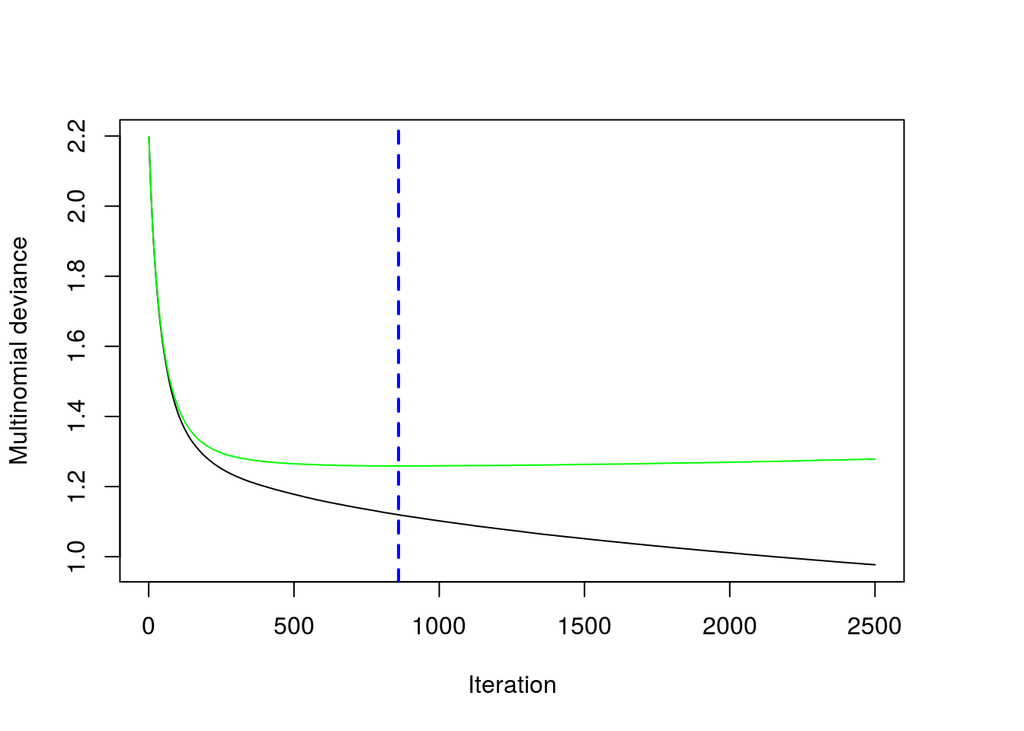

```r
    #Predict on the test data
    gbmocc0.predict=predict(gbmocc0,Finalocc.test,type="response", n.trees =best.iter)

    #Assign the class with maximum probability:
    pred.occ=apply(gbmocc0.predict,1,which.max)

    # Error:
    actual.occ=Finalocc.test$occ
    occ.table=table(actual.occ, pred.occ)

    #Classficiation Error
    print(paste0("Overall Misclassification rate",1-sum(diag(occ.table))/sum(occ.table)))
```

```
## [1] "Overall Misclassification rate0.430495689655172"
```

```r
    #Misclassification for each class
    print(paste0("Misclassification rate for Professional/Managerial",1-occ.table[1,1]/sum(occ.table[1,]) ))
```

```
## [1] "Misclassification rate for Professional/Managerial0.222984562607204"
```

```r
    print(paste0("Misclassification rate for Sales Worker",1-occ.table[2,2]/sum(occ.table[2,]) ))
```

```
## [1] "Misclassification rate for Sales Worker0.953020134228188"
```

```r
    print(paste0("Misclassification rate for Factory worker/Laborer/Driver",1-occ.table[3,3]/sum(occ.table[3,]) ))
```

```
## [1] "Misclassification rate for Factory worker/Laborer/Driver0.716867469879518"
```

```r
    print(paste0("Misclassification rate for Clerical/Service Worker",1-occ.table[4,4]/sum(occ.table[4,]) ))
```

```
## [1] "Misclassification rate for Clerical/Service Worker0.710900473933649"
```

```r
    print(paste0("Misclassification rate for Homemaker",1-occ.table[5,5]/sum(occ.table[5,]) ))
```

```
## [1] "Misclassification rate for Homemaker0.391608391608392"
```

```r
    print(paste0("Misclassification rate for Student/HS or College",1-occ.table[6,6]/sum(occ.table[6,]) ))
```

```
## [1] "Misclassification rate for Student/HS or College0.250764525993884"
```

```r
    print(paste0("Misclassification rate for Military",1-occ.table[7,7]/sum(occ.table[7,]) ))
```

```
## [1] "Misclassification rate for Military0.674418604651163"
```

```r
    print(paste0("Misclassification rate for retired",1-occ.table[8,8]/sum(occ.table[8,]) ))
```

```
## [1] "Misclassification rate for retired0.16025641025641"
```

```r
    print(paste0("Misclassification rate for Unemployed",1-occ.table[9,9]/sum(occ.table[9,]) ))
```

```
## [1] "Misclassification rate for Unemployed0.846153846153846"
```

- 9b.

```r
  summary(gbmocc0)
```

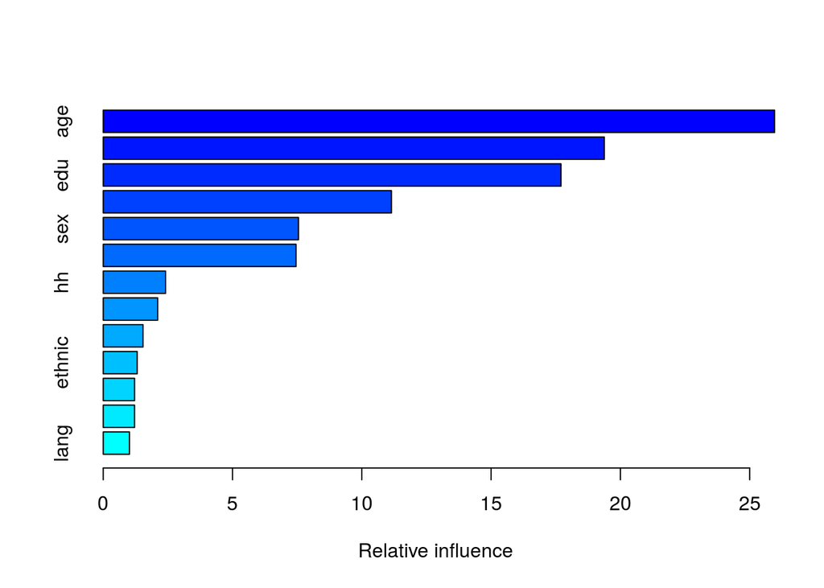

```
##                 var   rel.inf
## age             age 25.963151
## Inc             Inc 19.378973
## edu             edu 17.702209
## house         house 11.146211
## sex             sex  7.550540
## dual           dual  7.455251
## hh               hh  2.409436
## marital     marital  2.105662
## dwelltime dwelltime  1.538799
## ethnic       ethnic  1.312185
## hh18           hh18  1.212070
## hometype   hometype  1.211225
## lang           lang  1.014290
```

- Most important variables as an indicator for Occupation
  - Age:
  - Education:
  - Income